# diabetes

### Get the data, review the data by taking a look at a few of the rows.

Here is the difinition of each attribute

- age: age in years
- sex
- bmi: body mass index
- bp: average blood pressure
- s1: tc, total serum cholesterol
- s2: ldl, low-density lipoproteins
- s3: hdl, high-density lipoproteins
- s4: tch, total cholesterol / HDL
- s5: ltg, possibly log of serum triglycerides level
- s6: glu, blood sugar level

```python
from sklearn.pipeline import Pipeline
from sklearn import datasets
from sklearn.linear_model import LinearRegression
from sklearn.preprocessing import PolynomialFeatures
from sklearn.metrics import r2_score
from typing import List
from sklearn.metrics import mean_absolute_percentage_error
from sklearn.metrics import mean_absolute_error
from sklearn.preprocessing import PolynomialFeatures
import pandas as pd
import seaborn as sns
import matplotlib.pyplot as plt
import numpy as np
import math


plt.style.use("ggplot")


pd.set_option("display.max_columns", 200)


diabetes = datasets.load_diabetes()


df = pd.DataFrame(diabetes.data, columns=diabetes.feature_names)


print(df.shape, "\n")


print(df.isna().sum(), "\n")


print(df.head(5), "\n")


print(df.dtypes, "\n")


print(df.count(), "\n")


print(df.describe())
```

```
(442, 10)

age    0
sex    0
bmi    0
bp     0
s1     0
s2     0
s3     0
s4     0
s5     0
s6     0
dtype: int64

        age       sex       bmi        bp        s1        s2        s3
0  0.038076  0.050680  0.061696  0.021872 -0.044223 -0.034821 -0.043401  \
1 -0.001882 -0.044642 -0.051474 -0.026328 -0.008449 -0.019163  0.074412
2  0.085299  0.050680  0.044451 -0.005670 -0.045599 -0.034194 -0.032356
3 -0.089063 -0.044642 -0.011595 -0.036656  0.012191  0.024991 -0.036038
4  0.005383 -0.044642 -0.036385  0.021872  0.003935  0.015596  0.008142

         s4        s5        s6
0 -0.002592  0.019907 -0.017646
1 -0.039493 -0.068332 -0.092204
2 -0.002592  0.002861 -0.025930
3  0.034309  0.022688 -0.009362
4 -0.002592 -0.031988 -0.046641

age    float64
sex    float64
bmi    float64
bp     float64
s1     float64
s2     float64
s3     float64
s4     float64
s5     float64
s6     float64
dtype: object

```

[output cut: 16 more lines]

```
min   -1.072256e-01 -4.464164e-02 -9.027530e-02 -1.123988e-01 -1.267807e-01
25%   -3.729927e-02 -4.464164e-02 -3.422907e-02 -3.665608e-02 -3.424784e-02
50%    5.383060e-03 -4.464164e-02 -7.283766e-03 -5.670422e-03 -4.320866e-03
75%    3.807591e-02  5.068012e-02  3.124802e-02  3.564379e-02  2.835801e-02
max    1.107267e-01  5.068012e-02  1.705552e-01  1.320436e-01  1.539137e-01

                 s2            s3            s4            s5            s6
count  4.420000e+02  4.420000e+02  4.420000e+02  4.420000e+02  4.420000e+02
mean   3.918434e-17 -5.777179e-18 -9.042540e-18  9.293722e-17  1.130318e-17
std    4.761905e-02  4.761905e-02  4.761905e-02  4.761905e-02  4.761905e-02
min   -1.156131e-01 -1.023071e-01 -7.639450e-02 -1.260971e-01 -1.377672e-01
25%   -3.035840e-02 -3.511716e-02 -3.949338e-02 -3.324559e-02 -3.317903e-02
50%   -3.819065e-03 -6.584468e-03 -2.592262e-03 -1.947171e-03 -1.077698e-03
75%    2.984439e-02  2.931150e-02  3.430886e-02  3.243232e-02  2.791705e-02
max    1.987880e-01  1.811791e-01  1.852344e-01  1.335973e-01  1.356118e-01
```

### Frequency plot of BMI

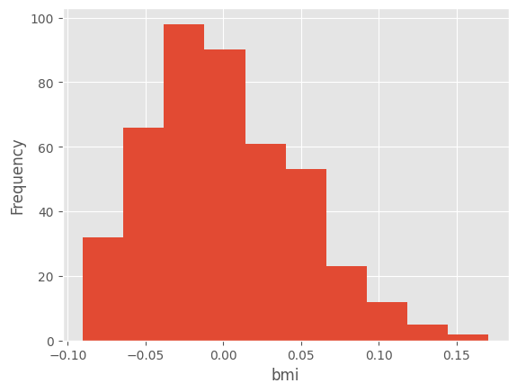

```python
ax = df['bmi'].plot(kind="hist")
ax.set_xlabel('bmi')
```

### Pairplot

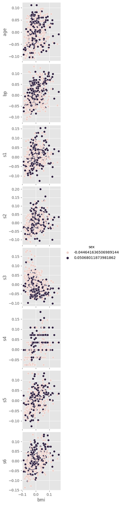

```python
sns.pairplot(
    data=df,
    x_vars=["bmi"],
    y_vars=["age", "bp", "s1", "s2", "s3", "s4", "s5", "s6"],
    hue='sex'
)
```

> Aboved graphics are the scatterplot for x equal `bmi`, then y stand for `age, bp, s1, s2, s5, s6`. As those show there are positive correlations between age, bp, s1, s2, s5, s6, and BMI. On the other hand, it looks like a negtive correlation for s3 to bmi. But the most weird thing is, s4 (total cholesterol) display 6 parallel lines on the graphic. I do have take a look to the original source (https://www4.stat.ncsu.edu/~boos/var.select/diabetes.tab.txt), around 10% data's total cholesterol are float type, it should be include more float type data after all for most situation, it is nearly impossible to close to a inter number of a health metricx. So for this step, I would exclude the s4 from the target of the dependent variable.

### Heat Map

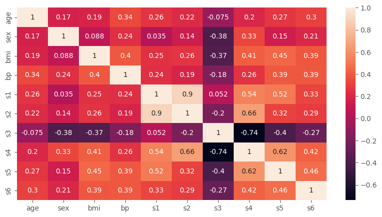

```python
pearson = df.corr(method="pearson")
plt.figure(figsize=(10, 5))
sns.heatmap(pearson, annot=True)
```

> When focusing on the column of BMI, it is observed that values closer to zero have a weaker correlation with the target variable (BMI). Among the positively correlated attributes, we find bp, s4, s5, and s6 with correlation values of 0.4, 0.41, 0.45 and 0.39. On the other hand, as mentioned earlier, S3 has a negative correlation with BMI. However, there is interesting thing, not only for BMI, S3 hold a negitive correlation but also with others attributes.

### Boxplots

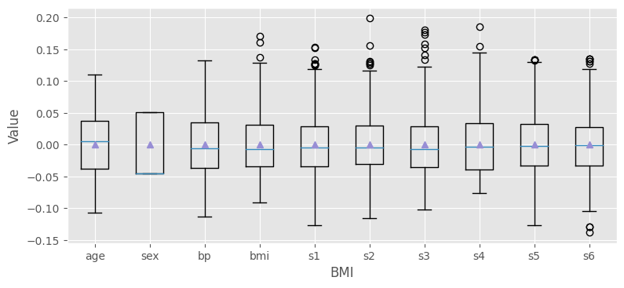

```python
fig = plt.figure(figsize=(7, 3))

ax = fig.add_axes([0, 0, 1, 1])
bp = ax.boxplot(df[["age", "sex", "bp", "bmi", "s1", "s2", "s3", "s4", "s5", "s6"]], showmeans=True)

ax.set_xticklabels(["age", "sex", "bp", "bmi", "s1", "s2", "s3", "s4", "s5", "s6"])
# plt.title("BMI of penguins")
plt.xlabel("BMI")
plt.ylabel("Value")

plt.show()
```

> By observing the box plots, except for `sex`` which only includes two values, the other variables seem to share a similar pattern and range of data distribution. Additionally, there are a few outliers in BMI, S1, S2, S3, S4, S5, and S6.

### Clean data

```python
df.isna().sum()
```

```
age    0
sex    0
bmi    0
bp     0
s1     0
s2     0
s3     0
s4     0
s5     0
s6     0
dtype: int64
```

> Since there are no missing values in the dataset, I will not make any changes. Although there are outliers in several attributes, including BMI, so I will not address the handling of outliers. Furthermore, according to the description of this dataset, the values have been standardized and scaled. This preprocessing step is known to enhance the performance of modeling.

### Split the dataset to a train (70%), validation (15%) and test (15%) sets

```python
train_size = int(len(df) * 0.7)
validation_test = int(len(df) * 0.15)

train = df[:train_size]
validation = df[train_size+validation_test:]
test = df[train_size:train_size+validation_test]

total = len(train) + len(test) + len(validation)

print(f"train: {math.ceil(len(train) / total * 100)}%, validation: {math.floor(len(validation) / total * 100)}%, test: {math.ceil(len(test) / total * 100)}%")
```

```
train: 70%, validation: 15%, test: 15%
```

### Run a polynomial regression on the BMI feature versus the " disease progression one year after baseline"

```python
# Function "create_polynomial_models" is from github repo: CSCN8010 ( https://github.com/CSCN8010/CSCN8010 ) by Professor Ran Feldesh.
def create_polynomial_models(X: np.ndarray, y: np.ndarray, degrees: List[int]) -> dict[int, np.poly1d]:
    """
    Creates polynomial models for the given degrees and fits them to the given data.

    Args
        X: The x values of the data.
        y: The y values of the data.
        degrees: A list of polynomial degrees to try.

    Returns:
        A dictionary of polynomial models, with the polynomial degree as the key.
    """

    models = {}
    for degree in degrees:
        model = Pipeline([('polynomial', PolynomialFeatures(degree=degree)),
                          ('linear', LinearRegression())])
        model.fit(X, y)
        models[degree] = model
    return models
```

```python
# Load Y value (disease progression one year after baseline) from download file.
Y_df = pd.read_csv("./data/diabetes.csv")

degrees = list(range(0, 6))
# Run modeling
models = create_polynomial_models(
    train["bmi"].to_numpy().reshape(-1, 1),
    Y_df[:train_size]["Y"].to_numpy().reshape(-1, 1),
    degrees,
)
```

```python
# Function "print_model_details" is from github repo: CSCN8010 ( https://github.com/CSCN8010/CSCN8010 ) by Professor Ran Feldesh.
def print_model_details(model):
    # print model
    print(f'Model: {model}')
    print(f'Coefficients: {model[-1].coef_[0][1:]}')
    print(f'Intercept: {model[-1].intercept_[0]}')
    # generate equation string:
    equation = f"y = {model[-1].intercept_[0]:.2f}"
    for ind, coeff in enumerate(model[-1].coef_[0][1:]):
        degree = ind + 1
        equation += f" + {coeff:.2f}x^{degree}"
    print(f'Equation: {equation}')
    print('***')

# print models
for degree, model in models.items():
    print_model_details(model)
```

```
Model: Pipeline(steps=[('polynomial', PolynomialFeatures(degree=0)),
                ('linear', LinearRegression())])
Coefficients: []
Intercept: 149.5210355987055
Equation: y = 149.52
***
Model: Pipeline(steps=[('polynomial', PolynomialFeatures(degree=1)),
                ('linear', LinearRegression())])
Coefficients: [976.10822731]
Intercept: 151.55092418989693
Equation: y = 151.55 + 976.11x^1
***
Model: Pipeline(steps=[('polynomial', PolynomialFeatures()),
                ('linear', LinearRegression())])
Coefficients: [ 935.76597284 1922.38555153]
Intercept: 147.33078993106037
Equation: y = 147.33 + 935.77x^1 + 1922.39x^2
***
Model: Pipeline(steps=[('polynomial', PolynomialFeatures(degree=3)),
                ('linear', LinearRegression())])
Coefficients: [  974.12034078  2416.45802164 -7889.74234439]
Intercept: 146.66772120640408
Equation: y = 146.67 + 974.12x^1 + 2416.46x^2 + -7889.74x^3
***
Model: Pipeline(steps=[('polynomial', PolynomialFeatures(degree=4)),
                ('linear', LinearRegression())])
Coefficients: [  1094.88348688    438.47727819 -39908.14884764 292748.82371806]
Intercept: 148.61697766121975
Equation: y = 148.62 + 1094.88x^1 + 438.48x^2 + -39908.15x^3 + 292748.82x^4
***
Model: Pipeline(steps=[('polynomial', PolynomialFeatures(degree=5)),
                ('linear', LinearRegression())])
Coefficients: [ 1.07939533e+03 -1.04498012e+03 -2.99337454e+04  5.26929052e+05
 -1.55293576e+06]
Intercept: 149.59312997905656
Equation: y = 149.59 + 1079.40x^1 + -1044.98x^2 + -29933.75x^3 + 526929.05x^4 + -1552935.76x^5
***
```

```python
for degree, model in models.items():
    y_pred_train = model.predict(
        train["bmi"].to_numpy().reshape(-1, 1)
    )
    print(f"Degree => {degree}")
    print("Train data")
    print(f"R-squared: {r2_score(Y_df[:train_size]['Y'].to_numpy().reshape(-1, 1), y_pred_train)}")
    print(f"MAPE: {mean_absolute_percentage_error(Y_df[:train_size]['Y'], y_pred_train)}")
    print(f"MAE: {mean_absolute_error(Y_df[:train_size]['Y'], y_pred_train)}\n")


    y_pred_train = model.predict(
        validation["bmi"].to_numpy().reshape(-1, 1)
    )
    print("Validation data")
    print(f"R-squared: {r2_score(Y_df[train_size+validation_test:]['Y'].to_numpy().reshape(-1, 1), y_pred_train)}")
    print(f"MAPE: {mean_absolute_percentage_error(Y_df[train_size+validation_test:]['Y'], y_pred_train)}")
    print(f"MAE: {mean_absolute_error(Y_df[train_size+validation_test:]['Y'], y_pred_train)}")


    # print(f"Degree => {degree}\n")
    # # validation data
    # print("Validation data")
    # print(f"R-squared: {model.score(validation['bmi'].to_numpy().reshape(-1, 1), Y_df[train_size+validation_test:]['Y'])}")
    # print(f"MAPE: {mean_absolute_percentage_error(validation['bmi'], Y_df[train_size+validation_test:]['Y'])}")
    # print(f"MAE: {mean_absolute_error(validation['bmi'], Y_df[train_size+validation_test:]['Y'])}\n")

    # # Train data
    # print(f"R-squared: {model.score(train['bmi'].to_numpy().reshape(-1, 1), Y_df[:train_size]['Y'])}")
    # print(f"MAPE: {mean_absolute_percentage_error(train['bmi'], Y_df[:train_size]['Y'])}")
    # print(f"MAE: {mean_absolute_error(train['bmi'], Y_df[:train_size]['Y'])}")

    print("-----------------------------------")
```

```
Degree => 0
Train data
R-squared: 0.0
MAPE: 0.6285007633022878
MAE: 65.69952137074392

Validation data
R-squared: -0.00022619292779801903
MAPE: 0.6820342308811447
MAE: 67.89025745061103
-----------------------------------
Degree => 1
Train data
R-squared: 0.3391503044527786
MAPE: 0.48879771700533403
MAE: 52.19634802757251

Validation data
R-squared: 0.3538523087303762
MAPE: 0.5202865439563414
MAE: 51.91205842533073
-----------------------------------
Degree => 2
Train data
R-squared: 0.3438067683933749
MAPE: 0.4848556049729502
MAE: 51.8014663893258

Validation data
R-squared: 0.34523056606790203
MAPE: 0.5249761107168485
MAE: 52.22754376845433
-----------------------------------
Degree => 3
Train data
R-squared: 0.3441850396545787
MAPE: 0.48340981662094956
MAE: 51.71986277769281

Validation data
```

[output cut: 11 more lines]

```
R-squared: 0.3509953081941153
MAPE: 0.5203136449423094
MAE: 51.815067088656185
-----------------------------------
Degree => 5
Train data
R-squared: 0.34665261614871634
MAPE: 0.48159327356735704
MAE: 51.59159413660315

Validation data
R-squared: 0.35252928043076703
MAPE: 0.5202362188374028
MAE: 51.811145435561805
-----------------------------------
```

```python
for degree, model in models.items():
    if degree == 5:

        y_pred_train_final = model.predict(test["bmi"].to_numpy().reshape(-1, 1))
        print(
            f"R-squared: {r2_score(Y_df[train_size:train_size+validation_test]['Y'].to_numpy().reshape(-1, 1), y_pred_train_final)}"
        )
        print(
            f"MAPE: {mean_absolute_percentage_error(Y_df[train_size:train_size+validation_test]['Y'], y_pred_train_final)}"
        )
        print(
            f"MAE: {mean_absolute_error(Y_df[train_size:train_size+validation_test]['Y'], y_pred_train_final)}"
        )
```

```
R-squared: 0.26146024622354425
MAPE: 0.348106001316894
MAE: 50.14818016721631
```

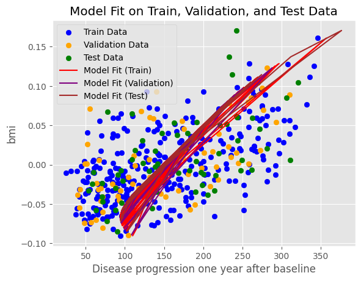

```python
for degree, model in models.items():
    if degree == 5:
        y_pred_train_plot = model.predict(train["bmi"].to_numpy().reshape(-1, 1))
        y_pred_test_plot = model.predict(test["bmi"].to_numpy().reshape(-1, 1))
        y_pred_val_plot = model.predict(validation["bmi"].to_numpy().reshape(-1, 1))

        plt.scatter(
            Y_df[:train_size]["Y"], train["bmi"], label="Train Data", color="blue"
        )
        plt.scatter(
            Y_df[train_size + validation_test :]["Y"],
            validation["bmi"],
            label="Validation Data",
            color="orange",
        )
        plt.scatter(
            Y_df[train_size : train_size + validation_test]["Y"],
            test["bmi"],
            label="Test Data",
            color="green",
        )

        plt.plot(
            y_pred_train_plot, train[["bmi"]], label="Model Fit (Train)", color="red"
        )
        plt.plot(
            y_pred_val_plot,
            validation[["bmi"]],
            label="Model Fit (Validation)",
            color="purple",
        )
        plt.plot(
            y_pred_test_plot, test[["bmi"]], label="Model Fit (Test)", color="brown"
        )

        plt.title("Model Fit on Train, Validation, and Test Data")
        plt.xlabel("Disease progression one year after baseline")
        plt.ylabel("bmi")

        plt.legend()
        plt.show()
```

### Write down the equation of the best model (with a two decimal digit precision, assuming it's sufficient). Manually calculate the expected diabetes progression for a BMI value of your choice, and compare it to model.perdict() for that value.

```python
for degree, model in models.items():
    if degree == 5:
        equation = f"y = {model[-1].intercept_[0]:.2f}"
        for ind, coeff in enumerate(model[-1].coef_[0][1:]):
            degree = ind + 1
            equation += f" + {coeff:.2f}x^{degree}"
        print(f'Equation: {equation}')

        pred_bmi_from_model = model.predict([[0.00133873]])
        print(pred_bmi_from_model)
```

```
Equation: y = 149.59 + 1079.40x^1 + -1044.98x^2 + -29933.75x^3 + 526929.05x^4 + -1552935.76x^5
[[151.03620594]]
```

> Equation: y = 149.59 + 1079.40x^1 + -1044.98x^2 + -29933.75x^3 + 526929.05x^4 + -1552935.76x^5

I choose bmi value equal to `0.00133873`, than put it into the equation: y = 149.59 + 1079 * `0.00133873` + -1044.9 * `0.00133873` * `0.00133873` + -29933.75 * `0.00133873` * `0.00133873` * `0.00133873` + 526929.05 * `0.00133873` * `0.00133873` * `0.00133873` * `0.00133873` + -1552935.76 * `0.00133873` * `0.00133873` * `0.00133873` * `0.00133873` * `0.00133873`

```python
prd_bmi_manually_calculate = 149.59 + 1079.4 * 0.00133873 + (-1044.9 * 0.00133873 * 0.00133873) + (-29933.75 * 0.00133873 * 0.00133873 * 0.00133873) + (526929.05 * 0.00133873 * 0.00133873 * 0.00133873 * 0.00133873) + (-1552935.76 * 0.00133873  * 0.00133873 * 0.00133873 * 0.00133873 * 0.00133873)
print(prd_bmi_manually_calculate)

abs(prd_bmi_manually_calculate-pred_bmi_from_model)
```

```
151.03308236097524
```

```
array([[0.00312358]])
```

> The gap between the predicted BMI value by model and the manually calculated BMI value is: 0.00312358

```python
poly = PolynomialFeatures(degree=5)
poly_features = poly.fit_transform(df)
feature_names = poly.get_feature_names_out(df.columns)

print(feature_names)
```

```
['1' 'age' 'sex' ... 's5^2 s6^3' 's5 s6^4' 's6^5']
```